# Project 1

# Overview

The goal of this analysis is to understand how to make the Orange Juice category of store sales perform better. The store sells two brands of orange juice, Minute Maid (MM) and Citrus Hill (CH). Since MM has higher margins than CH, this analysis will make recommendations regarding which factors influence a consumer’s decision to purchase MM orange juice. This allows our compaqny to leverage those factors as opportunities to influence MM sales. It will additionally provide a predictive model for more precise forecasting. This forecasting will be of benefit now, but will be of tremendous benefit later when the company adjusts its marketing to increase MM sales (since an updated forecast will be required).

# Problem Definition

Brand manager 1. What predictor variables influence the sales of MM?

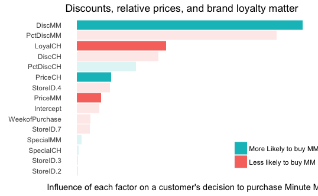

2. Are all the variables in the dataset effective or are some more effective than others?

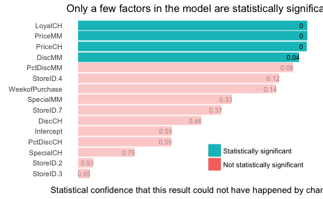

3. How confident are you in your recommendations?

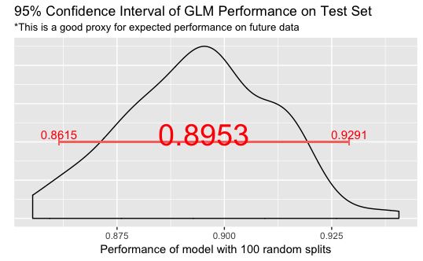

4. Based on your analysis what are specific recommendations you have for the brand manager?

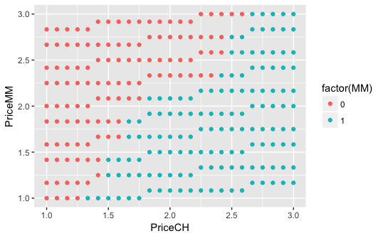

```r
h2o.predict(h2o_glm, as.h2o(sens_analysis_df2)) %>%
  as_tibble %>%
  mutate_at(2:4, round, digits = 3) %>%
  mutate(MM = ifelse(MM > .5,1,0)) %>%
  bind_cols(sens_analysis_df2) %>%
  select(PriceCH, PriceMM, MM) %>%
  ggplot(aes(PriceCH, PriceMM, color = factor(MM))) +
    geom_point()
```

Sales manager 1. Can you provide him a predictive model that can tell him the probability of customers buying MM? 2. How good is the model in its predictions? 3. How confident are you in your recommendations?

# Recommendations

```r
table(df$Purchase, df$StoreID) %>%
  as_tibble %>%
  ggplot(aes(Var2, n, fill = Var1)) +
    geom_bar(stat = "identity", position = "fill")
```

[output not shown]